# Luke Bryan Spotify Analysis

Amanda Suleski

10/20/2019

Luke Bryan is a pop country artist. He has won numerous CMT awards, American Country Awards, Country Music Association Awards, and Billboard Music Awards in addition to being on both American Idol and The Voice. I am analyzing the danceability and valence in Luke Bryan’s songs. Danceability describes how suitable a track is for dancing based on a combination of musical elements including tempo, rhythm stability, beat strength, and overall regularity. Valence describes the musical positiveness conveyed by a song.

The nonparametric procedures that will be used are the Sign Test, Permutation Test, Wilcoxon Test, Kruskal Wallace Test, ANOVA, and the Conover Test. The Sign Test subtracts the null hypothesis median from each data point, then all we need to know about the differences is whether they are positive or negative. The test statistic is the number of positive signs. A sufficient assumption is that the observations are an iid sample. The test is considered nonparametric because no parametric distribution is assumed for the population. The Permutation Test assumes exchangeability; this means that every permutation of the two samples put together is equally likely. The Permutation Test takes two exchangeable samples and lists all possible combinations or simulates a large number of permutations for small sample sizes and large sample sizes respectively. For each permutation it compares the two permuted samples using a test statistic. The Wilcoxon-Mann-Whitney test is a nonparametric statistical test that compares two paired groups. The test essentially calculates the difference between each set of pairs and analyzes these differences. It can be used to test the null hypothesis that two populations have the same continuous distribution. The Kruskal Wallace Test, or one-way ANOVA on ranks, is a non-parametric method for testing whether samples originate from the same distribution. It is used for comparing two or more independent samples. ANOVA analyzes the differences among group means in a sample. This assumes normality and homoscedasticity of the data. The Conover Test is a method of performing pairwise comparisons between groups. It is a pairwise comparison procedure that is a better alternative to the Tukey procedure.

```
##    Min. 1st Qu.  Median    Mean 3rd Qu.    Max.
##  0.2640  0.5150  0.5630  0.5617  0.6160  0.7390
```

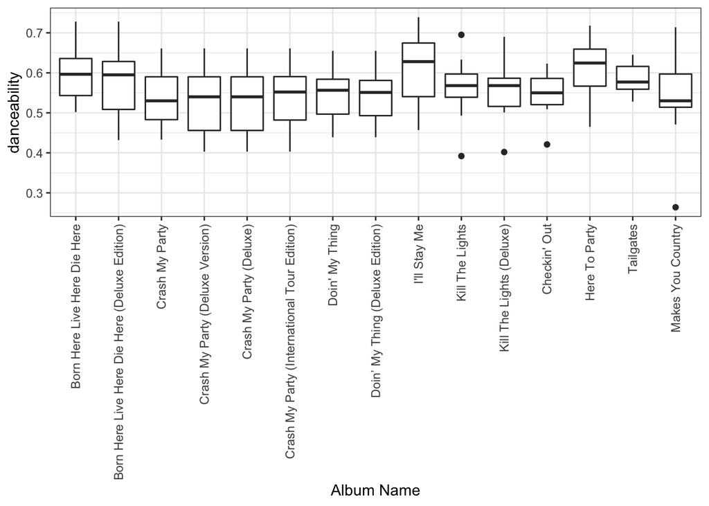

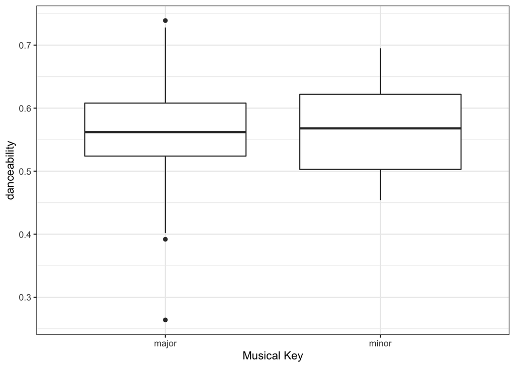

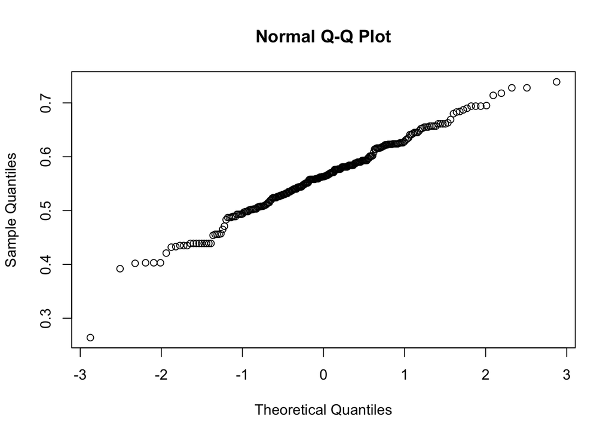

For danceability, the median and mean are both slightly above 0.5 which means the majority of the songs are more danceable than not. The minimum and maximum tell us that no song is completely danceable or completely not danceable. The first boxplot shows that there are few outliers in the data. The biggest outlier is in the What Makes You Country album with danceability just above 0.25. Kill the Lights has two outliers at about 0.4 and 0.7 and Spring Break…Checkin’ Out has an outlier just above 0.4. Most of the outliers have low danceability scores which means the majority of the songs are danceable with only 3 that are not very danceable. I’ll Stay Me and Spring Break… Here to Party are the most danceable albums with the mean around 0.625. The rest of the albums have means which are all about 0.55. Danceability appears to have the same distribution for both major and minor songs. There is one outlier in the qqplot, but besides that the data is normal. This aligns with my opinions of Luke Bryan’s music. Country music is usually not completely danceable, but I have definitely danced to most of his songs at barn dances.

```
##    Min. 1st Qu.  Median    Mean 3rd Qu.    Max.
##  0.1380  0.4108  0.5440  0.5531  0.6993  0.9620
```

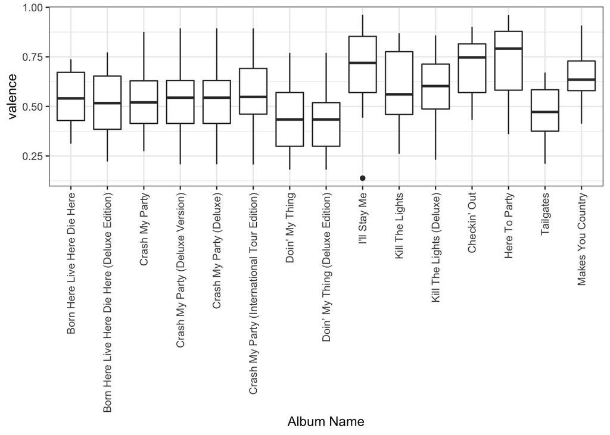

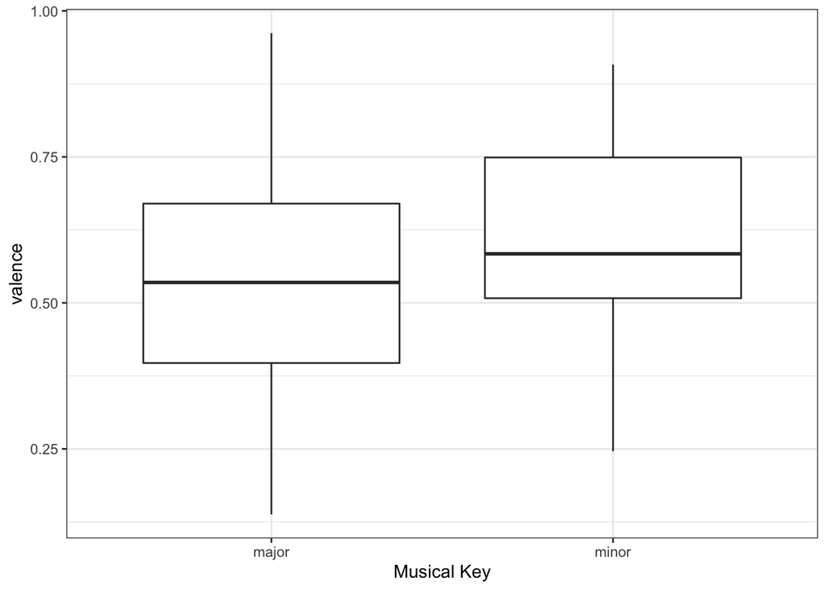

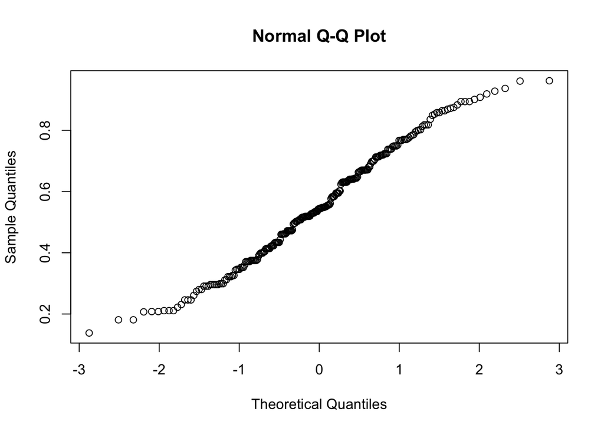

```
##
##  One-sample Sign-Test
##
## data:  luke$danceability
## s = 204, p-value < 2.2e-16
## alternative hypothesis: true median is not equal to 0.5
## 95 percent confidence interval:
##  0.558 0.576
## sample estimates:
## median of x
##       0.563
##
## Achieved and Interpolated Confidence Intervals:
##
##                   Conf.Level L.E.pt U.E.pt
## Lower Achieved CI     0.9347  0.558  0.576
## Interpolated CI       0.9500  0.558  0.576
## Upper Achieved CI     0.9512  0.558  0.576
```

```
##
##  One-sample Sign-Test
##
## data:  luke$valence
## s = 153, p-value = 0.0002785
## alternative hypothesis: true median is not equal to 0.5
## 95 percent confidence interval:
##  0.5190000 0.5816346
## sample estimates:
## median of x
##       0.544
##
## Achieved and Interpolated Confidence Intervals:
##
##                   Conf.Level L.E.pt U.E.pt
## Lower Achieved CI     0.9347  0.519 0.5770
## Interpolated CI       0.9500  0.519 0.5816
## Upper Achieved CI     0.9512  0.519 0.5820
```

```
## [1] 0.8886
```

```
## [1] 0.0238
```

```
##
##  Exact Wilcoxon-Mann-Whitney Test
##
## data:  luke$danceability by luke$mode_name (major, minor)
## Z = 0.068914, p-value = 0.9457
## alternative hypothesis: true mu is not equal to 0
```

```
##
##  Exact Wilcoxon-Mann-Whitney Test
##
## data:  luke$valence by luke$mode_name (major, minor)
## Z = -2.2051, p-value = 0.02715
## alternative hypothesis: true mu is not equal to 0
```

```
##
##  Kruskal-Wallis rank sum test
##
## data:  danceability by album_name
## Kruskal-Wallis chi-squared = 24.52, df = 14, p-value = 0.03961
```

```
##
##  Kruskal-Wallis rank sum test
##
## data:  valence by album_name
## Kruskal-Wallis chi-squared = 46.725, df = 14, p-value = 2.133e-05
```

```
## Analysis of Variance Table
##
## Response: danceability
##             Df  Sum Sq   Mean Sq F value  Pr(>F)
## album_name  14 0.14596 0.0104257  2.0878 0.01324 *
## Residuals  233 1.16350 0.0049936
## ---
## Signif. codes:  0 '***' 0.001 '**' 0.01 '*' 0.05 '.' 0.1 ' ' 1
```

```
## Analysis of Variance Table
##
## Response: valence
##             Df Sum Sq Mean Sq F value    Pr(>F)
## album_name  14 1.7470 0.12478  4.0805 2.427e-06 ***
## Residuals  233 7.1252 0.03058
## ---
## Signif. codes:  0 '***' 0.001 '**' 0.01 '*' 0.05 '.' 0.1 ' ' 1
```

These results make sense because certain albums like the spring break albums are much more of a party playlist (for spring break), so these albums will have more positive and danceable songs than albums like Doin’ My Thing. Since there was such a wide range in valence for Luke Bryan’s songs it makes sense that there is stronger evidence for different distributions across albums. Since there was a small range in danceability it makes sense that there is only weak evidence because all the songs, except for a few outliers, are within the same range. So we would expect only a small difference in distributions across albums.

```
##   Kruskal-Wallis rank sum test
##
## data: x and group
## Kruskal-Wallis chi-squared = 24.5198, df = 14, p-value = 0.04
##
##
##                            Comparison of x by group
##                              (Benjamini-Hochberg)
## Col Mean-|
## Row Mean |   Born Her   Born Her   Crash My   Crash My   Crash My   Crash My
## ---------+------------------------------------------------------------------
## Born Her |   0.509217
##          |     0.4650
## Crash My |   1.786916   1.463185
##          |     0.1646     0.2235
## Crash My |   1.713466   1.371143  -0.186611
##          |     0.1649     0.2311     0.5084
## Crash My |   1.713466   1.371143  -0.186611   0.000000
##          |     0.1710     0.2371     0.5142     0.5000
## Crash My |   1.656918   1.302801  -0.289746  -0.106443  -0.106443
##          |     0.1730     0.2368     0.5068     0.4854     0.4904
## Doin' My |   1.681772   1.325255  -0.344457  -0.157304  -0.157304  -0.046665
##          |     0.1701     0.2446     0.4983     0.4940     0.4994     0.4908
## Doin’ My |   1.719077   1.386765  -0.072749   0.109163   0.109163   0.210469
##          |     0.1825     0.2367     0.4849     0.4942     0.4994     0.5148
## I'll Sta |  -0.440972  -1.016012  -2.304986  -2.262643  -2.262643  -2.217135
##          |     0.4810     0.3329     0.1654     0.1290     0.1434     0.1114
## Kill The |   0.812377   0.365383  -1.045077  -0.925958  -0.925958  -0.849099
##          |     0.3845     0.5006     0.3249     0.3521     0.3588     0.3787
## Kill The |   1.120852   0.697372  -0.802869  -0.663284  -0.663284  -0.576156
##          |     0.3074     0.4185     0.3828     0.4166     0.4232     0.4428
## Spring B |   1.415830   1.055337  -0.324639  -0.166018  -0.166018  -0.075766
##          |     0.2307     0.3337     0.5019     0.5009     0.5065     0.4884
## Spring B |  -0.597371  -1.236758  -2.593573  -2.577405  -2.577405  -2.540052
##          |     0.4382     0.2594     0.2651     0.1387     0.1850     0.1232
## Tailgate |   0.169829  -0.488655  -2.158956  -2.142481  -2.142481  -2.098594
##          |     0.5104     0.4692     0.1116     0.0968     0.1025     0.1020
## What Mak |   1.424123   1.046539  -0.449211  -0.286428  -0.286428  -0.190883
##          |     0.2336     0.3311     0.4834     0.4961     0.5022     0.5182
## Col Mean-|
```

[output cut: 13 more lines]

```
##          |     0.4952     0.1087     0.4931     0.2029     0.1367     0.1071
## Tailgate |  -2.207851  -2.069856   0.740703  -0.879003  -1.319137  -1.635713
##          |     0.1059     0.1039     0.4090     0.3697     0.2413     0.1694
## What Mak |  -0.156773  -0.373908   1.950005   0.632545   0.360507  -0.093775
##          |     0.4890     0.5029     0.1309     0.4262     0.4965     0.4858
## Col Mean-|
## Row Mean |   Spring B   Tailgate
## ---------+----------------------
## Tailgate |   0.987073
##          |     0.3409
## What Mak |   2.230100   1.715474
##          |     0.1168     0.1769
##
## alpha = 0.1
## Reject Ho if p <= alpha/2
```

The conover test for danceability does not yield significant results. Certain albums such as Crash My Party and I’ll Stay Me or Spring Break… Here to Party, Doing My Thing and Spring Break… Here to Party or Tailgates & Tanlines, I’ll Stay Me and Spring Break…Checkin’ Out or What Makes You Country, Spring Break…Here To Party and Spring Break…Checkin’ Out or What Makes You Country produce p-values which are almost significant. However, we cannot reject the null hypothesis, that two albums have the same danceability distribution, for any of the album pairs.

```
##   Kruskal-Wallis rank sum test
##
## data: x and group
## Kruskal-Wallis chi-squared = 46.7249, df = 14, p-value = 0
##
##
##                            Comparison of x by group
##                              (Benjamini-Hochberg)
## Col Mean-|
## Row Mean |   Born Her   Born Her   Crash My   Crash My   Crash My   Crash My
## ---------+------------------------------------------------------------------
## Born Her |   0.466974
##          |     0.3824
## Crash My |   0.266469  -0.203968
##          |     0.4366     0.4539
## Crash My |   0.145598  -0.373852  -0.146722
##          |     0.4508     0.4135     0.4592
## Crash My |   0.145598  -0.373852  -0.146722   0.000000
##          |     0.4552     0.4181     0.4638     0.5000
## Crash My |  -0.299404  -0.899515  -0.636373  -0.524178  -0.524178
##          |     0.4365     0.2551     0.3404     0.3625     0.3667
## Doin' My |   1.244633   0.868228   1.034879   1.294749   1.294749   1.906454
##          |     0.1909     0.2633     0.2330     0.1948     0.1986     0.0759
## Doin’ My |   1.255073   0.909678   1.060159   1.275348   1.275348   1.791656
##          |     0.1907     0.2617     0.2274     0.1942     0.1978     0.0931
## I'll Sta |  -1.746397  -2.428799  -2.136187  -2.121913  -2.121913  -1.705303
##          |     0.0979    0.0348*     0.0571     0.0555     0.0573     0.1044
## Kill The |  -0.737259  -1.334652  -1.076379  -0.999170  -0.999170  -0.536583
##          |     0.3030     0.1887     0.2250     0.2391     0.2425     0.3657
## Kill The |  -0.787305  -1.430100  -1.150142  -1.077753  -1.077753  -0.590614
##          |     0.2870     0.1650     0.2163     0.2280     0.2315     0.3556
## Spring B |  -2.023280  -2.737675  -2.431493  -2.434558  -2.434558  -2.024620
##          |     0.0663    0.0206*    0.0360*    0.0374*    0.0392*     0.0680
## Spring B |  -2.386068  -3.213907  -2.855946  -2.898137  -2.898137  -2.472745
##          |    0.0374*    0.0071*    0.0154*    0.0144*    0.0154*    0.0390*
## Tailgate |   1.198917   0.797355   0.976979   1.262583   1.262583   1.937068
##          |     0.2028     0.2868     0.2437     0.1916     0.1950     0.0726
## What Mak |  -1.596088  -2.336809  -2.015354  -2.003198  -2.003198  -1.547872
##          |     0.1276    0.0410*     0.0656     0.0640     0.0657     0.1374
## Col Mean-|
```

[output cut: 13 more lines]

```
##          |    0.0006*    0.0019*     0.3608     0.0974     0.0873     0.4357
## Tailgate |  -0.167656  -0.321446   3.479912   2.295269   2.500424   3.834279
##          |     0.4598     0.4316    0.0045*    0.0440*    0.0382*    0.0021*
## What Mak |  -3.402996  -3.112724   0.280774  -0.901196  -0.929964   0.585539
##          |    0.0046*    0.0084*     0.4352     0.2579     0.2577     0.3534
## Col Mean-|
## Row Mean |   Spring B   Tailgate
## ---------+----------------------
## Tailgate |   4.534899
##          |    0.0005*
## What Mak |   0.905046  -3.543415
##          |     0.2599    0.0042*
##
## alpha = 0.1
## Reject Ho if p <= alpha/2
```

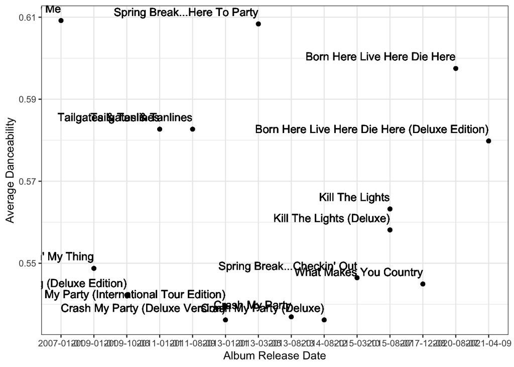

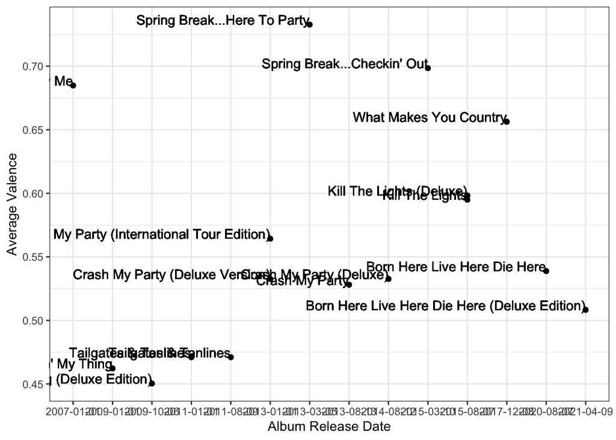

It appears that Luke Bryan’s songs were slightly more danceable in the beginning of his career with the exception of the Doin’ My Thing album. There is such a small range for danceability so there is no sufficient evidence for a strong trend in danceability across Luke Bryan’s career. Again with valence, there is no sufficient evidence for a strong trend in valence across his career. From 2009-2011, he hit low points for valence with the average under 0.5 and then the valence is above 0.5 for the following years.

```
##               Pearson  Spearman   Kendall
## Correlation 0.4188482 0.3986452 0.2719736
```

Pearson is a measure of the linear correlation between two variables; it is the ratio of the covariance of the variables to the product of their standard deviations. The Spearman correlation between two variables is equal to the Pearson correlation between the rank of the variables. It is better than Pearson’s correlation coefficient when dealing with outliers and nonlinear data. The Kendall rank correlation is less sensitive to outliers. Spearman and Kendall coefficients are probably more accurate because Pearson assumes linearity. Pearson produced the highest correlation coefficient, followed by Spearman then Kendall.

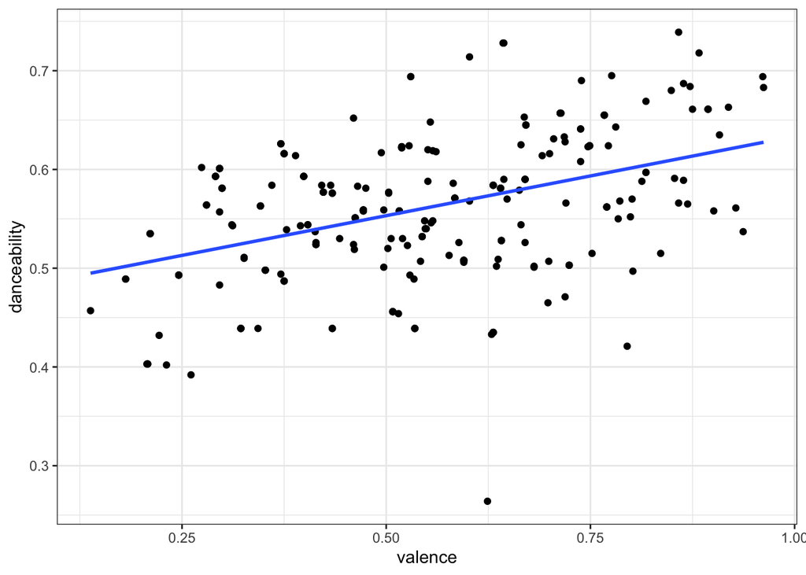

The plot shows a slightly positive relationship between danceability and valence. “Out of Nowhere Girl” from the What Makes You Country album is a low leverage outlier with danceability just above 0.25.

The data was broken into groups by album to check if the correlation changes. As previously concluded, all Luke Bryan’s albums have a small range in scores for danceability which can be explained by a relatively similar beat across albums. He has a much wider range in valence. This is accounted for by his wide variety of song topics which include trucks breaking down and break-ups in addition to hunting and fishing.

```
##                                                   Pearson    Spearman
## Born Here Live Here Die Here (Deluxe Edition)  0.54459311  0.51104621
## Born Here Live Here Die Here                   0.47457898  0.43030303
## What Makes You Country                         0.30248545  0.24285714
## Kill The Lights                                0.66446619  0.58597029
## Kill The Lights (Deluxe)                       0.60347775  0.47275456
## Spring Break...Checkin' Out                   -0.17743390 -0.04545455
## Crash My Party (Deluxe)                        0.55531642  0.53742331
## Crash My Party                                 0.48249849  0.36263736
## Crash My Party (Deluxe Version)                0.55531642  0.53742331
## Crash My Party (International Tour Edition)    0.56742884  0.55160304
## Spring Break...Here To Party                   0.33901318  0.45494505
## Tailgates & Tanlines                           0.17499474  0.10178827
## Doin’ My Thing (Deluxe Edition)                0.38615329  0.37414066
## Doin' My Thing                                 0.36945801  0.35409844
## I'll Stay Me                                   0.72483419  0.70909091
##                                                   Kendall
## Born Here Live Here Die Here (Deluxe Edition)  0.38656827
## Born Here Live Here Die Here                   0.37777778
## What Makes You Country                         0.16190476
## Kill The Lights                                0.42581531
## Kill The Lights (Deluxe)                       0.35295364
## Spring Break...Checkin' Out                   -0.05454545
## Crash My Party (Deluxe)                        0.41481481
## Crash My Party                                 0.28205128
## Crash My Party (Deluxe Version)                0.41481481
## Crash My Party (International Tour Edition)    0.42478061
## Spring Break...Here To Party                   0.34065934
## Tailgates & Tanlines                           0.03871048
## Doin’ My Thing (Deluxe Edition)                0.24516639
## Doin' My Thing                                 0.23106226
## I'll Stay Me                                   0.63636364
```

There is a wide range of correlation coefficients for valence and danceability across albums. The only negative coefficients are in the Spring Break…Checkin’ Out album. I’ll Stay Me has the strongest positive relationship between valence and danceability while Kill the Lights also has a strong positive relationship.

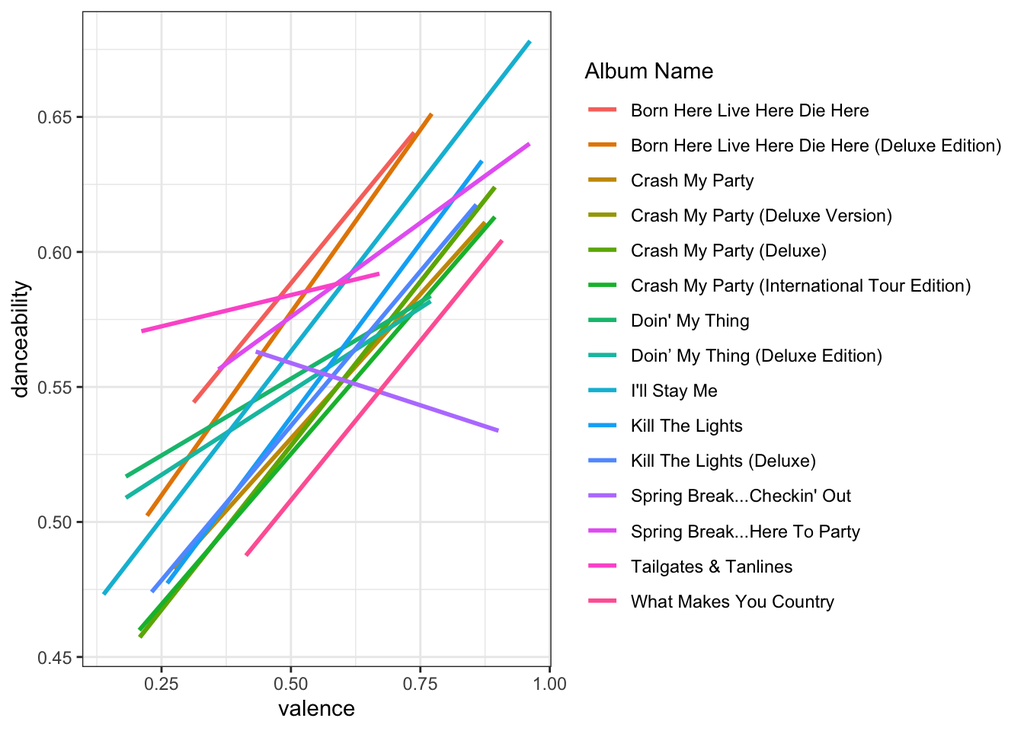

The plot shows that Spring Break…Checkin’ Out is the only negative relationship and Tailgates & Tanlines has the weakest positive relationship. Crash My Party and What Makes You Country, in addition to I’ll Stay Me and Kill the Lights, have similar positive relationships.

The data was also grouped into three year categories: Old songs (relased between 2007-2009), Mid songs (released between 2011-2013), and New songs (released between 2015-2017). This is to see if the relationships across albums are dependent on the date released.

```
##             Pearson  Spearman   Kendall
## 2007-2009 0.5762248 0.5449844 0.4042264
## 2011-2013 0.4064851 0.3554320 0.2443306
## 2015-2017 0.3733660 0.3846328 0.2554407
```

The older songs (years 2007-2009) have a much stronger positive correlation than the more recent songs. I’ll Stay Me was the album with the strongest positive relationship and was released in 2007. The songs after 2009 have similar correlation coefficients. The largest difference in coefficients from 2011-2013 and 2015-2017 is from the Pearson correlation. This could be due to the “Out of Nowhere Girl” outlier from 2017.

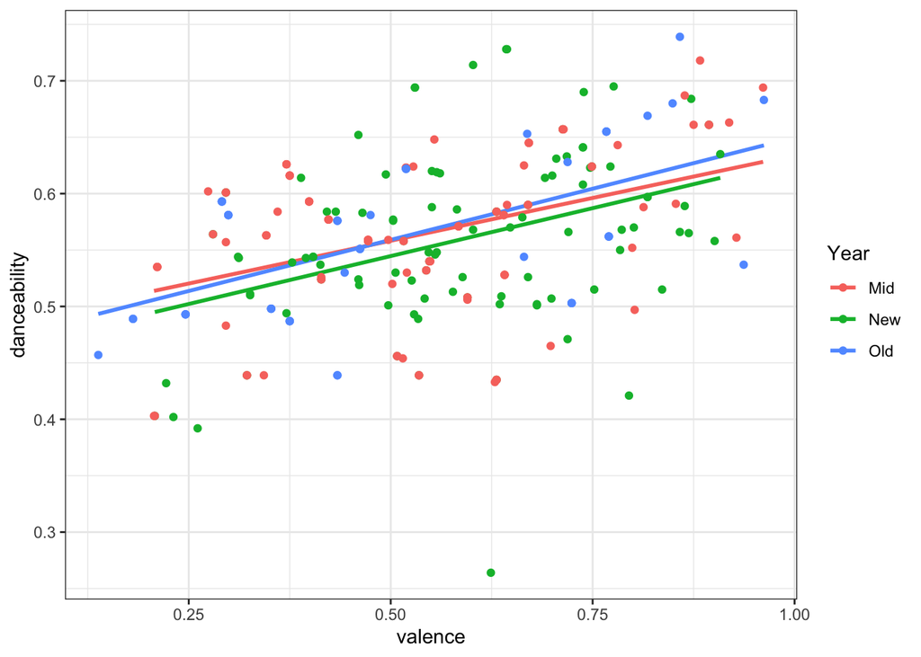

As shown by the plot, the old songs have the strongest relationship and the mid and new songs have a similar relationship.

This can be expected due to the wide variety in Luke Bryan’s early music. In his first two albums, the songs range from a slower and sadder “Someone Else Calling You Baby” to an upbeat “Rain is a Good Thing.” By the halfway point in his career, Luke Bryan has found the type of music he’s best at and has remained around a pretty constant danceability, even with ranging valence, hence the weaker relationships.

Bootstrapping is a method for approximating sampling distributions of estimators. Bootstrapping involves taking a random sample with replacement from the sample observations and calculating the statistic on the resampled data. Bootstrapping produces a consistent estimate of the standard error of estimators. It works when no parametric model is feasible or is tractable. However, it is based on random sampling so results will change a little bit every time and if you have a bad sample, your results will be bad.

```
## BOOTSTRAP CONFIDENCE INTERVAL CALCULATIONS
## Based on 10000 bootstrap replicates
##
## CALL :
## boot.ci(boot.out = boot.dist, conf = 0.99)
##
## Intervals :
## Level      Normal              Basic
## 99%   ( 0.2520,  0.5486 )   ( 0.2582,  0.5570 )
##
## Level     Percentile            BCa
## 99%   ( 0.2403,  0.5391 )   ( 0.2414,  0.5398 )
## Calculations and Intervals on Original Scale
```

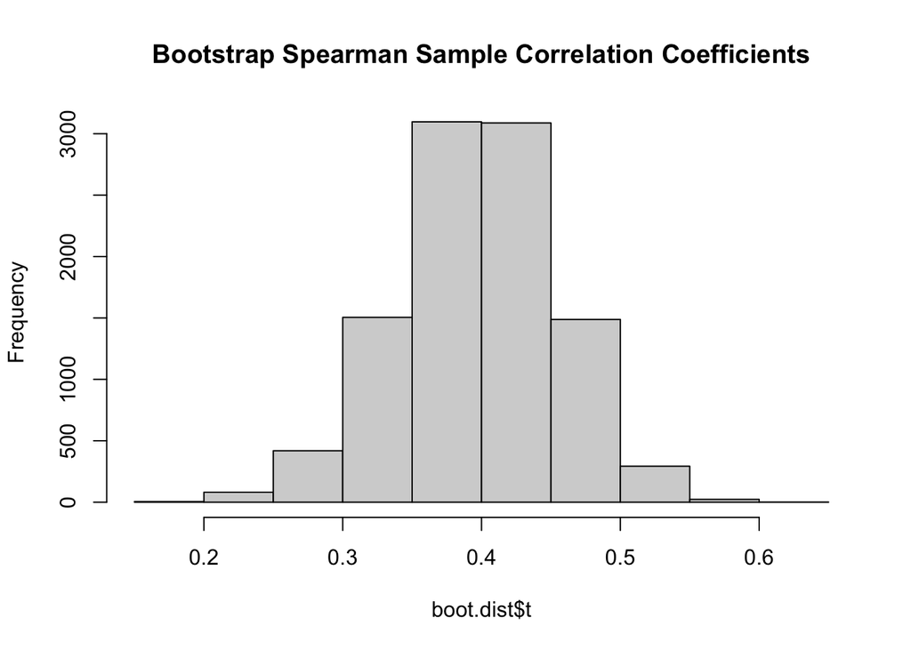

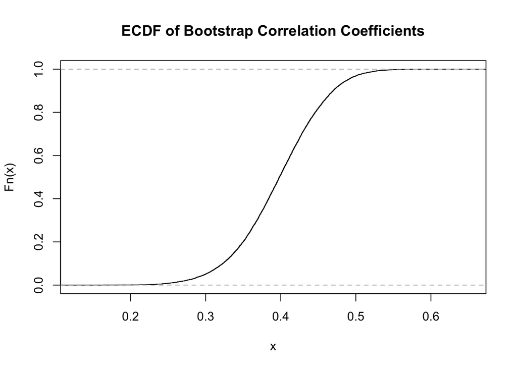

```
## [1] 0.09740674
```

```
## [1] "New"
## BOOTSTRAP CONFIDENCE INTERVAL CALCULATIONS
## Based on 10000 bootstrap replicates
##
## CALL :
## boot.ci(boot.out = boot.dist, conf = 0.99)
##
## Intervals :
## Level      Normal              Basic
## 99%   ( 0.1659,  0.6135 )   ( 0.1707,  0.6212 )
##
## Level     Percentile            BCa
## 99%   ( 0.1480,  0.5986 )   ( 0.1495,  0.6004 )
## Calculations and Intervals on Original Scale
## [1] 0.1343091
## [1] "Mid"
## BOOTSTRAP CONFIDENCE INTERVAL CALCULATIONS
## Based on 10000 bootstrap replicates
##
## CALL :
## boot.ci(boot.out = boot.dist, conf = 0.99)
##
## Intervals :
## Level      Normal              Basic
## 99%   ( 0.0992,  0.6194 )   ( 0.1322,  0.6355 )
##
## Level     Percentile            BCa
## 99%   ( 0.0753,  0.5787 )   ( 0.0806,  0.5822 )
## Calculations and Intervals on Original Scale
## [1] 0.1545998
## [1] "Old"
## BOOTSTRAP CONFIDENCE INTERVAL CALCULATIONS
## Based on 10000 bootstrap replicates
##
## CALL :
## boot.ci(boot.out = boot.dist, conf = 0.99)
##
## Intervals :
## Level      Normal              Basic
## 99%   ( 0.2412,  0.8683 )   ( 0.2888,  0.9254 )
##
## Level     Percentile            BCa
## 99%   ( 0.1646,  0.8012 )   ( 0.1683,  0.8012 )
## Calculations and Intervals on Original Scale
## [1] 0.2158158
```

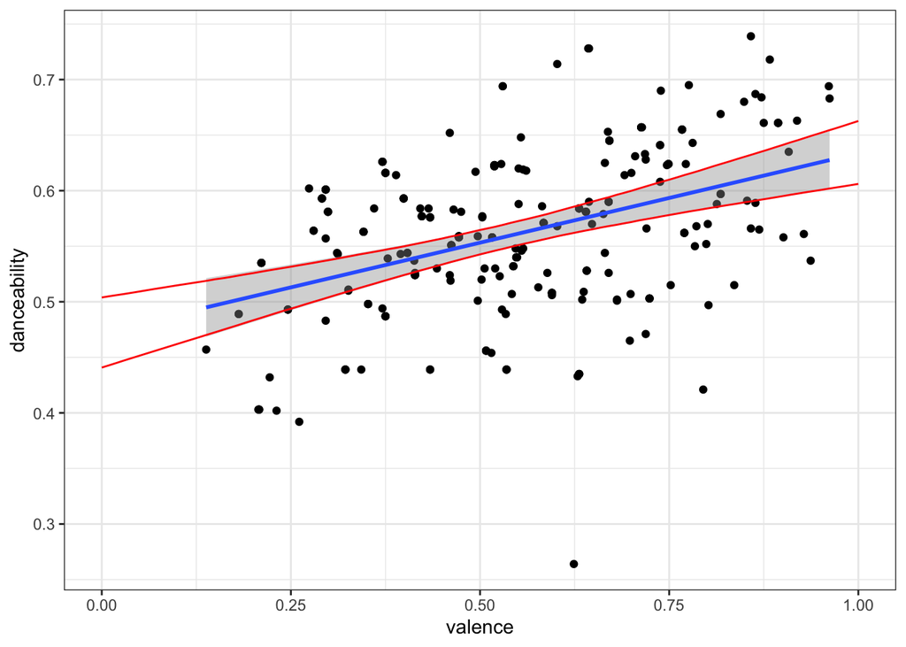

Notice how the upper bootstrap bound (red) deviates from the standard linear models band. It is slightly lower for low valence levels and slightly above the standard linear models band for high levels of valence.

The univariate density plots are created using the Sheather-Jones bandwidth. The default is Gaussian; however, this is not good. Also “Unless told otherwise, just use density(x, bw =”SJ“)” (from lecture notes).

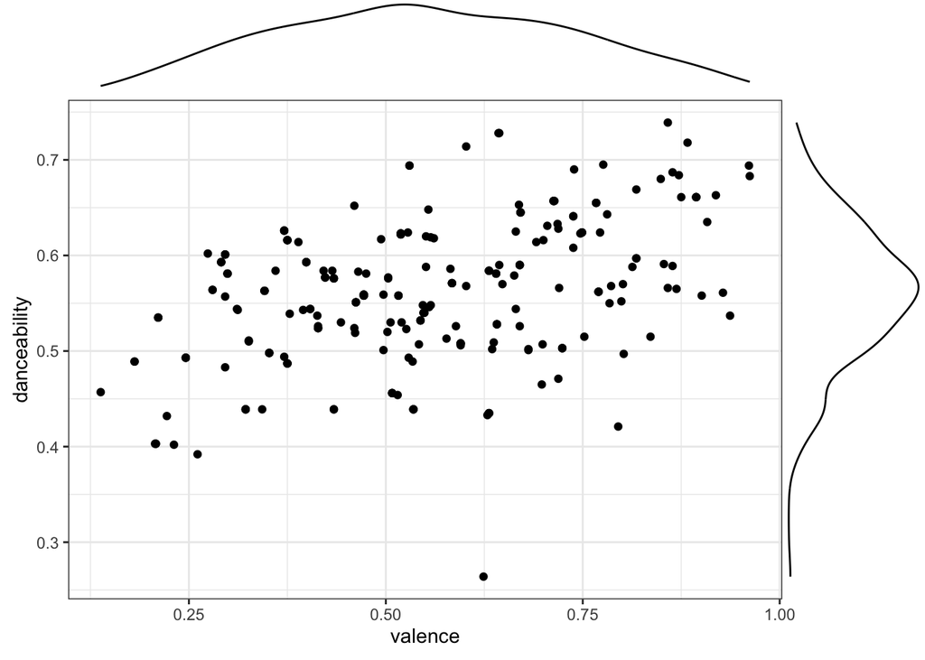

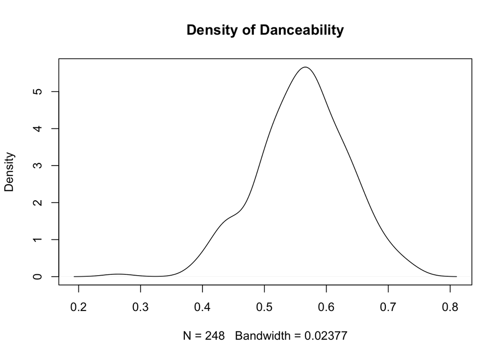

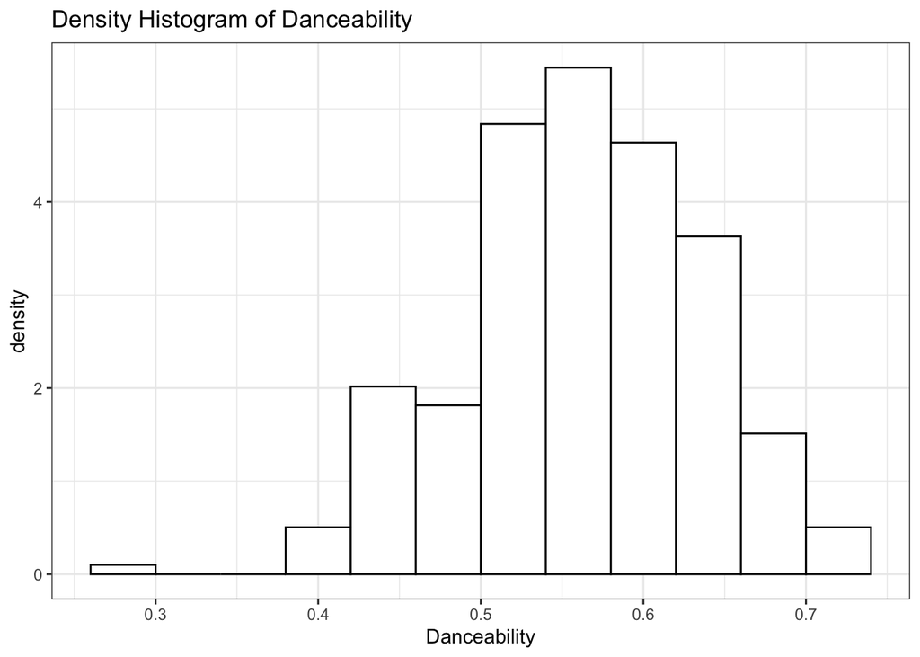

There is a high peak in danceability density between danceability values of 0.5-0.6. The density distribution for danceability is left-skewed. There is the one song which is an outlier with a danceability score of about 0.25. The density histogram resembles the density plot above. The binwidth is 0.04 in order to accurately capture the density curve.

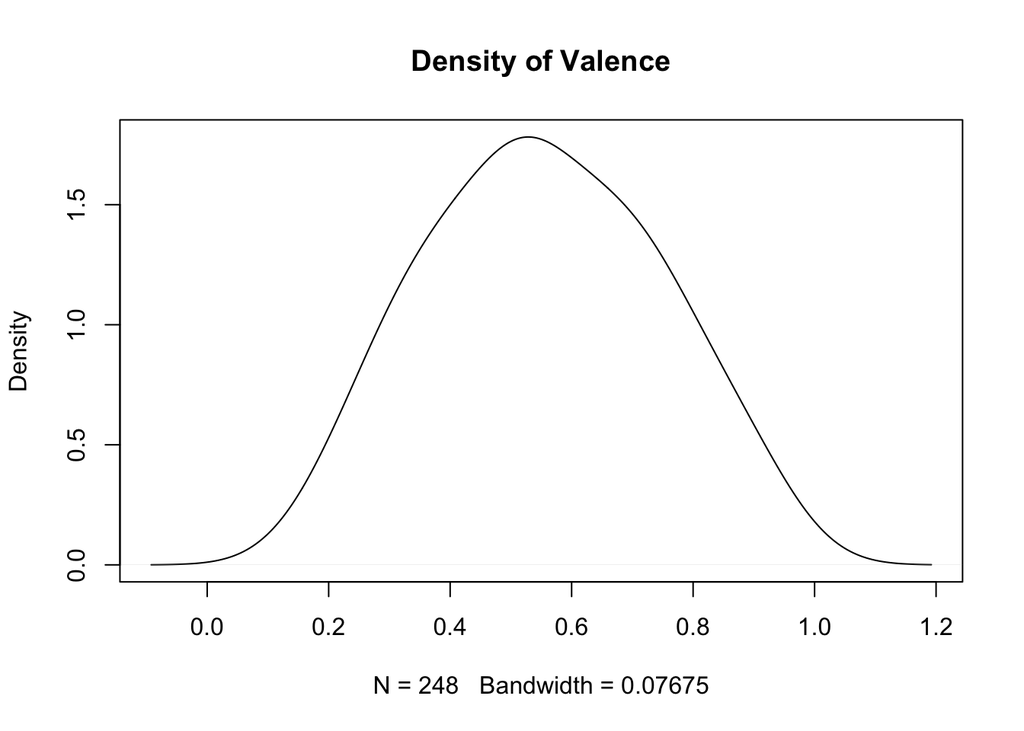

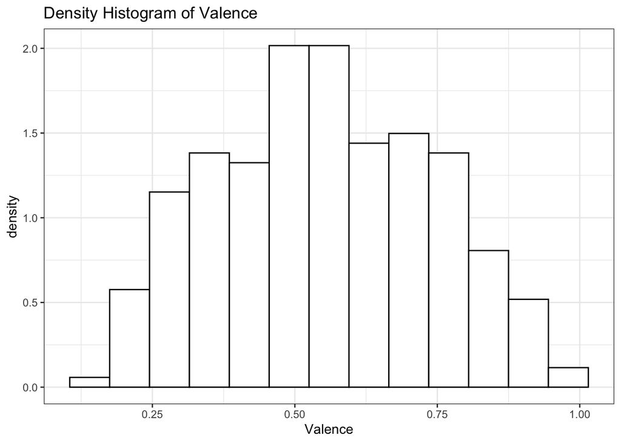

The density of valence is centered around 0.5 and almost resembles a normal curve. The density histogram resembles the density plot above. The binwidth is 0.07 in order to accurately capture the density curve without overfitting.

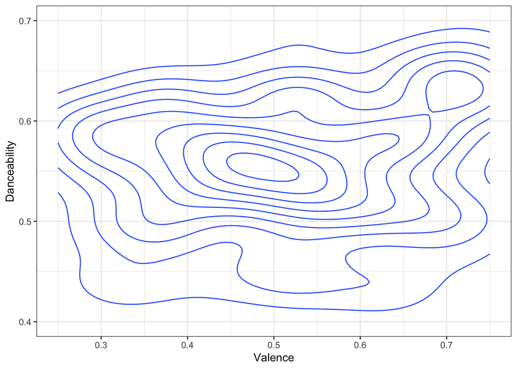

One can see that most of the data is centered around 0.55 danceability and 0.45 valence. It is interesting to note that there is another dense location where danceability is about 0.65 and valence about 0.7. The bottom left corner’s shape is probably due to the one outlier with a very low danceability.

Conditional densities are found by
$$\hat{f}_{Y|X}(y|x) = \frac{\hat{f}_{X,Y}(x,y)}{\hat{f}_X(x)}$$

[output not shown]

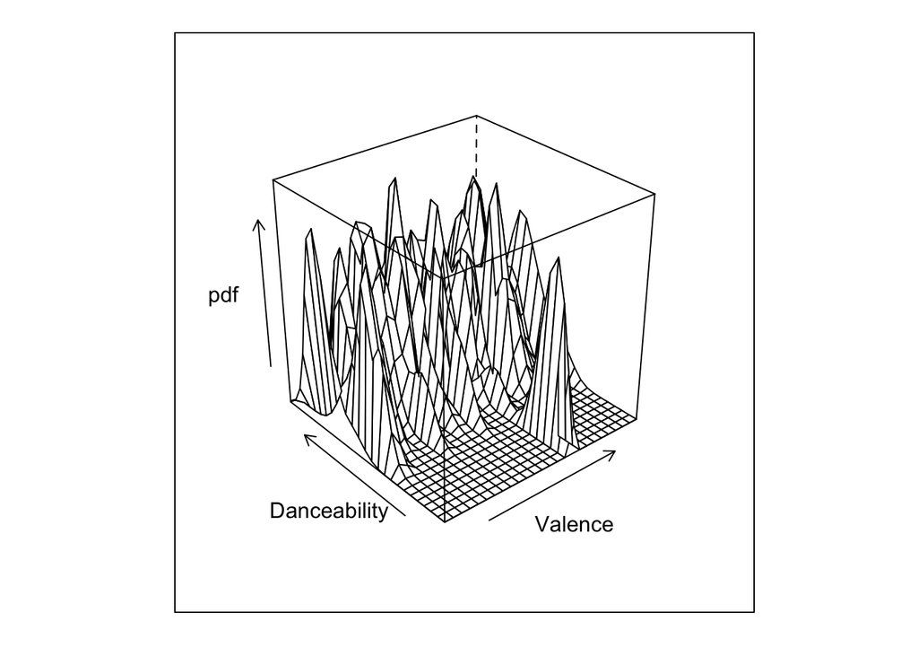

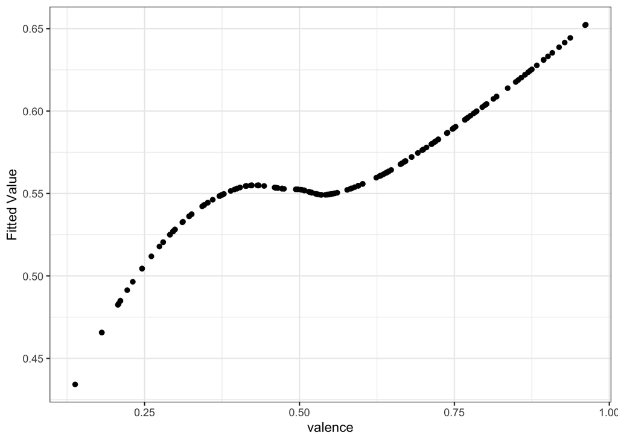

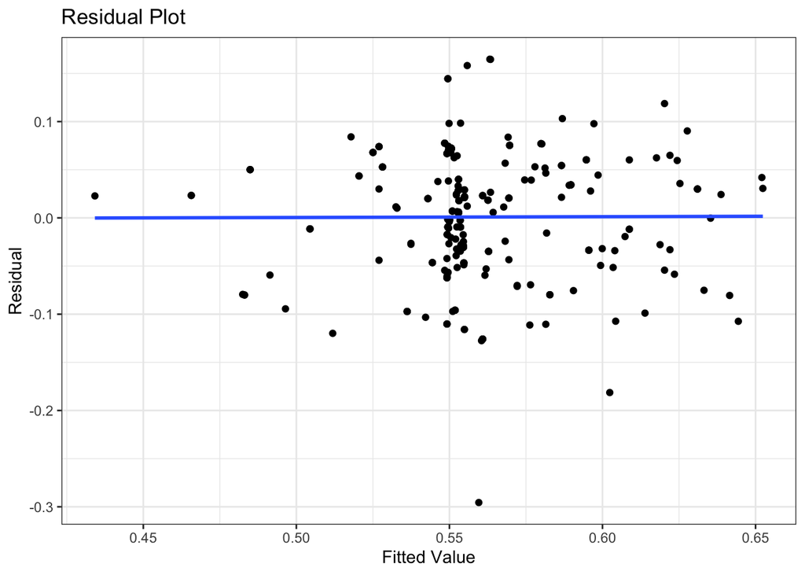